# The Effect of Loan Variables on Loan Amount

## by Chimamaka Chilaka

## Investigation Overview

> In this analysis, I am interested in determining the variable that affects the loan amount given to borrowers and will be focusing on the Monthly loan payment, Term and IsborrowerHomeowner.

## Dataset Overview

> The data consisted of Loan Original Amount and other features of approximately 114,000 rows of loan data. The dataset was subsetted to get only features for which i was interested in analysing further. The features included StatedMonthlyIncome, DebttoIncome Ratio, Loan Term, Prosper risk score and some other relevant variables. Some data were removed altogether due to inconsistencies noticed.

## Loan Original Amount Distribution

> There is a spike between 0-5k, 10k-15k, 15k-20k(All in dollars). This most likely depicts that the loan is given in multiples of 5k and as a rounded figure. Also, i observed from the plot that majority of the loan seems to have been disbursed at 4k, 10k and 15k causing the distribution to be somewhat tri-modal.

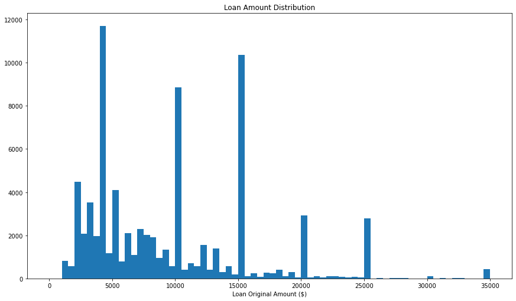

## Distribution of Monthly Payment

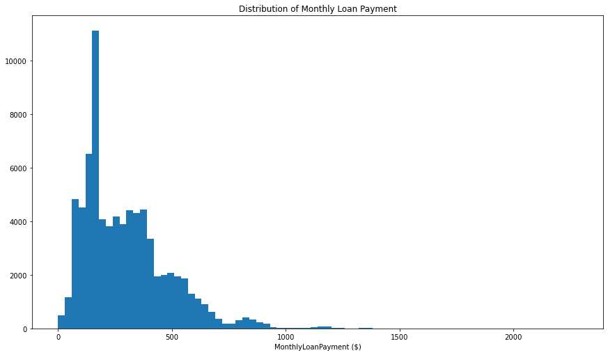

## Loan Amount By Monthly Payment

> There is a positive corelation between LoanOriginalAmount and MonthlyLoanPayment which could stem from the fact that the repayment amount is calculated from the Loan amount and more loan will most likely have a higher amount when calculated.

> The plot is split in three parts which could mean that there is a categorical variable affecting this.

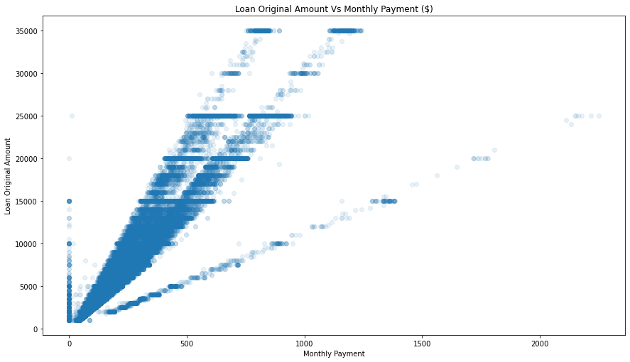

## Loan Amount Across Term and Monthly Payment

> The Term seems to affect the Loan Original Amount and the Monthly loan payment. Borrowers with a lesser term tend to have hogher monthly payment as compared to those with higher term. This could be because the amount to be paid is spread across a longer period.

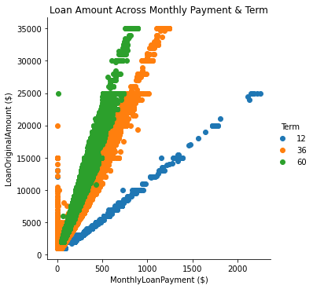

## Loan Amount Across IsBorrowerHomeowner and EmploymentStatus

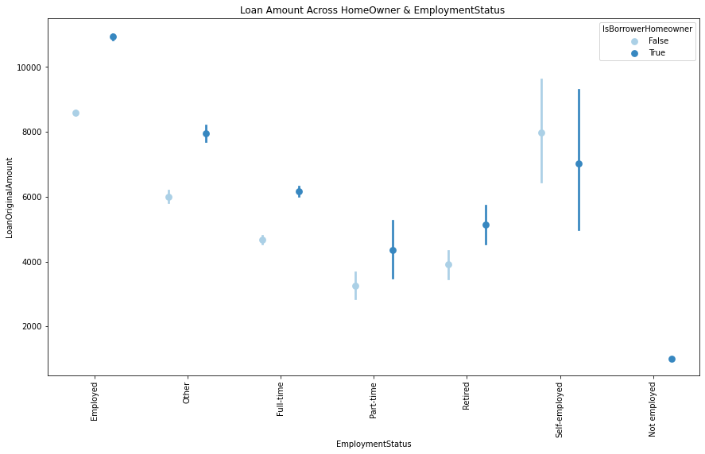